# ggplot2 R

Linze Yu

2022-03-06

# 1 加载包

```r
> library("YuriR")#
> library("MASS")#smooth
> library("mgcv")#smooth
> library("hexbin")#六边形封箱热图
> library("ggpointdensity")#散点图和二维密度图之间的交叉
> library("ggExtra")#边际直方图/密度曲线
> library("ggbeeswarm")#散点防止重合
> library("fBasics")#正态性检验1
> library("timeDate")#正态性检验2
> library("timeSeries")#正态性检验3
> library("car")#方差齐性检验
> library("psych")#相关性检验
> library("ggrepel")#标签排斥
> library("ggradar")#雷达图
> library("ggpubr")#增加P值/*
> library("plotly")#交互网页
> library("tayloRswift")#泰勒专辑调色板
```

# 2 计算

| 序号 | 数学符号 | 解释 | 序号 | 比较符号 | 解释 | 序号 | 逻辑符号 | 解释 |
| --- | --- | --- | --- | --- | --- | --- | --- | --- |
| 1 | `+` | 加 | 1 | `>` | 大于 | 1 | `&` | 与 |
| 2 | `-` | 减 | 2 | `<` | 小于 | 2 | `\|` | 或 |
| 3 | `*` | 乘 | 3 | `> =` | 大于等于 | 3 | `!` | 非 |
| 4 | `/` | 除 | 4 | `< =` | 小于等于 |  |  |  |
| 5 | `^` | 幂指数 | 5 | `= =` | 等于 |  |  |  |
| 6 | `%%` | 余数 | 6 | `! =` | 不等于 |  |  |  |
| 7 | `%/%` | 整除 | 7 | `sign()` | 判断正负号 |  |  |  |
| 8 | `abs()` | 取绝对值 |  |  |  |  |  |  |
| 9 | `sqrt()` | 平方根 |  |  |  |  |  |  |
| 10 | `log2()` | 以二为底的对数 |  |  |  |  |  |  |
| 11 | `log10()` | 以十为底的对数 |  |  |  |  |  |  |
| 12 | `log(c, base = )` | 自定义底的对数 |  |  |  |  |  |  |
| 13 | `log(a, base = exp(1))` | 自然常数e的对数 |  |  |  |  |  |  |
| 14 | `round()` | 四舍六入五成双 |  |  |  |  |  |  |

# 3 统计

## 3.1 数据部分

### 3.1.1 分布类型

代码前加`r`生成相应分布的随机数  
代码前加`d`生成相应分布的密度函数  
代码前加`p`生成相应分布的累计概率密度函数  
代码前加`q`生成相应分布的分位数函数

| 序号 | 分布 | 代码 | 序号 | 分布 | 代码 |
| --- | --- | --- | --- | --- | --- |
| 1 | 平均分布 | `unif(n, min = , max = )` | 11 | 几何分布 | `geom(prob = )` |
| 2 | 正态分布 | `norm(n, mean = , sd = )` | 12 | 超几何分布 | `hyper(m = , n = , k = )` |
| 3 | 伽玛分布 | `gamma(shape = , rate = )` | 13 | 逻辑分布 | `logis(location = , scale = )` |
| 4 | Beta分布 | `beta(shape1, shape2, )` | 14 | 负二项分布 | `nbinom(size = , prob = )` |
| 5 | 二项分布 | `binom(size = , prob = )` | 15 | 多元正态分布 | `mvnorm(mean = , cov = )` |
| 6 | 柯西分布 | `cauchy(location = , scale = )` | 16 | 泊松分布 | `pois(lambda = )` |
| 7 | 卡方分布 | `chisq(df = )` | 17 | t分布 | `t(df = )` |
| 8 | 指数分布 | `exp(rate = )` | 18 | 威布儿分布 | `weibull(shape = , scale = )` |
| 9 | F分布 | `f(df1 = , df2 = )` | 19 | 威尔科森分布 | `wilcox(m = , n = )` |
| 10 | 指数分布 | `rexp(n, lamda = 1)`lamda＝1/mean |  |  |  |

## 3.2 检验

### 3.2.1 正态性检验

(fBasics包)  
`normalTest()`进行Kolmogorov-Smirnov正态性检验  
`ksnormTest()`进行Kolmogorov-Smirnov正态性检验  
`shapiroTest()`进行Shapiro-Wilk”s正态检验 W检验 3-5000  
`jarqueberaTest()`进行jarque-Bera正态性检验  
`dagoTest()`进行D”Agostino正态性检验  
`gofnorm()`采用13种方法进行检验, 并输出结果

### 3.2.2 方差齐性检验

(car包)  
`leveneTest(data, Group, center = mean)`  
`leveneTest(data, Group, center = median)`  
data.table(group = rep(c(“A”, “B”), each = 25), value = c(A, B))

### 3.2.3 基线资料表

(gtsummary包) modify_footnote(label~“列脚注”)%>% modify_spanning_header(label~“跨越式标头”)%>% bold_p()%>%#粗体有效p值

```r
> dt <- import("D:/desktop/book/book/case/case_MS/p131_4.xlsx")
> dt1 <- gather(dt, group, value, age, CO2, O2, pH)
> dt1 %>%
+  tbl_summary(by = group,
+  digits = all_continuous()~2,
+  type = all_continuous()~"continuous2",
+  #"continuous", "continuous2", "categorical", "dichotomous"
+  statistic = list(
+  all_continuous()~c("{mean}({sd})", "{median}({p25}, {p75})", "{min}, {max}"),
+  all_categorical()~"{n}/{N}({p}%)"),
+  missing = "always",
+  missing_text = "missing") %>%
+
+ modify_caption("50例老年单纯COPD患者的pH及有关指标")%>%
+ modify_header(label~"列标题")%>%
+ modify_footnote() %>%
+ bold_labels()%>%#粗体变量标签
+ bold_levels()%>%#粗体变量级别
+ italicize_labels()%>%#斜体化变量标签
+ italicize_levels()%>%#斜体化变量级别
+ add_n() %>%#添加非NA观测值个数
+ add_overall() %>%
+ add_p(pvalue_fun = ~style_pvalue(.x, digits = 3),
+  list(all_continuous()~"t.test",
+  all_categorical()~"fisher.test"))
```

```
Column Name   Column Header
------------  ----------------
label         列标题
stat_1        **age**, N = 50
stat_2        **CO2**, N = 50
stat_3        **O2**, N = 50
stat_4        **pH**, N = 50
```

50例老年单纯COPD患者的pH及有关指标

| 列标题 | **N** | **Overall**, N = 200<sup>1</sup> | **age**, N = 50<sup>1</sup> | **CO2**, N = 50<sup>1</sup> | **O2**, N = 50<sup>1</sup> | **pH**, N = 50<sup>1</sup> | **p-value**<sup>2</sup> |
| --- | --- | --- | --- | --- | --- | --- | --- |
| group1 | 200 |  |  |  |  |  | >0.999 |
| A |  | 116/200(58%) | 29/50(58%) | 29/50(58%) | 29/50(58%) | 29/50(58%) |  |
| B |  | 84/200(42%) | 21/50(42%) | 21/50(42%) | 21/50(42%) | 21/50(42%) |  |
| missing |  | 0 | 0 | 0 | 0 | 0 |  |
| value | 200 |  |  |  |  |  |  |
| Mean(SD) |  | 52.21(31.73) | 73.74(5.88) | 50.65(17.71) | 77.05(24.24) | 7.40(0.07) |  |
| Median(IQR) |  | 63.85(22.35, 75.00) | 72.50(69.25, 77.00) | 43.65(37.52, 60.22) | 74.40(65.40, 81.15) | 7.42(7.36, 7.46) |  |
| Range |  | 7.19, 188.50 | 65.00, 85.00 | 27.30, 103.80 | 44.00, 188.50 | 7.19, 7.50 |  |
| missing |  | 0 | 0 | 0 | 0 | 0 |  |

<sup>1</sup> n/N(%)  
<sup>2</sup> Fisher's exact test

```r
>  #"t.test""aov""wilcox.test""kruskal.test""chisq.test""fisher.test""lme4"
```

### 3.2.4 t检验

#### 3.2.4.1 单样本t检验

医学统计学P56

```r
> data <- import("D:/desktop/book/book/case/case_MS/P56_t.xlsx")
> A = data[, 1]
> shapiroTest(A)#正态性检验
```

```
Title:
 Shapiro - Wilk Normality Test

Test Results:
  STATISTIC:
    W: 0.9444
  P VALUE:
    0.2894

Description:
 Sun Mar 06 20:38:17 2022 by user: LinzeYu
```

```r
> ost <- t.test(A, mu = 14, alternative = "two.sided", conf.level = 0.95)#two.sided是双尾检验, less是左侧单尾检验, greater是右侧单尾检验
> ost
```

```
    One Sample t-test

data:  A
t = 7.9402, df = 19, p-value = 1.873e-07
alternative hypothesis: true mean is not equal to 14
95 percent confidence interval:
 16.37857 18.08143
sample estimates:
mean of x
    17.23
```

#### 3.2.4.2 配对样本t检验

医学统计学P57  
paired表示是否配对, 配对样本选T

```r
> data <- import("D:/desktop/book/book/case/case_MS/P57_t.xlsx")
> before = data[, 1]
> after = data[, 2]
> before
```

```
 [1] 10.12 11.00  8.11  7.42  7.53  9.39 11.15  8.95  7.98  8.91 11.08  8.90
[13]  9.74  8.76  9.25  8.37  9.11  8.37  9.76  8.89  7.11  7.22  9.30  8.39
[25]  9.71
```

```r
> after
```

```
 [1] 7.82 8.26 6.80 6.45 6.51 7.45 8.34 7.23 6.74 7.21 8.30 7.20 7.62 7.13 7.38
[16] 6.93 7.31 6.93 7.63 7.19 6.30 6.35 7.40 6.94 7.61
```

```r
> d = before-after
> d
```

```
 [1] 2.30 2.74 1.31 0.97 1.02 1.94 2.81 1.72 1.24 1.70 2.78 1.70 2.12 1.63 1.87
[16] 1.44 1.80 1.44 2.13 1.70 0.81 0.87 1.90 1.45 2.10
```

```r
> shapiroTest(d)#正态性检验
```

```
Title:
 Shapiro - Wilk Normality Test

Test Results:
  STATISTIC:
    W: 0.9602
  P VALUE:
    0.4182

Description:
 Sun Mar 06 20:38:17 2022 by user: LinzeYu
```

```r
> pt <- t.test(after, before, paired = TRUE, var.equal = T, conf.level = 0.95)
> pt
```

```
    Paired t-test

data:  after and before
t = -15.558, df = 24, p-value = 4.89e-14
alternative hypothesis: true difference in means is not equal to 0
95 percent confidence interval:
 -1.970377 -1.508823
sample estimates:
mean of the differences
                -1.7396
```

#### 3.2.4.3 独立样本t检验

##### 3.2.4.3.1 等方差

医学统计学P59  
paired表示是否配对, 独立样本选F

```r
> data <- import("D:/desktop/book/book/case/case_MS/P59_t.xlsx")
> A = data[, 1]
> B = data[, 2]
> A
```

```
 [1] 3.32 3.78 2.29 1.94 1.99 2.95 3.85 2.72 2.22 2.70 2.70 3.13 2.63 2.88 2.42
[16] 2.80 2.43 3.14 2.69 1.78 3.82 1.83
```

```r
> B
```

```
 [1] 2.32 2.78 1.29 0.94 0.99 1.95 2.85 1.72 1.22 1.70 2.82 1.70 2.13 1.63 1.88
[16] 1.42 1.80 1.43   NA   NA   NA   NA
```

```r
> shapiroTest(A)#正态性检验
```

```
Title:
 Shapiro - Wilk Normality Test

Test Results:
  STATISTIC:
    W: 0.9511
  P VALUE:
    0.332

Description:
 Sun Mar 06 20:38:17 2022 by user: LinzeYu
```

```r
> shapiroTest(B)#正态性检验
```

```
Title:
 Shapiro - Wilk Normality Test

Test Results:
  STATISTIC:
    W: 0.9349
  P VALUE:
    0.2368

Description:
 Sun Mar 06 20:38:17 2022 by user: LinzeYu
```

```r
> dt2 <- data.table(group = rep(c("A", "B"), each = 25), value = c(A, B))
> head(dt2)
```

```
    group value
   <char> <num>
1:      A  3.32
2:      A  3.78
3:      A  2.29
4:      A  1.94
5:      A  1.99
6:      A  2.95
```

```r
> leveneTest(value~group, data = dt2, center = mean)#方差齐性检验
```

```
Levene's Test for Homogeneity of Variance (center = mean)
      Df F value Pr(>F)
group  1  0.4274 0.5167
      44
```

```r
> wtst <- t.test(A, B, paired = F, var.equal = T, conf.level = 0.95)
> wtst
```

```
    Two Sample t-test

data:  A and B
t = 4.8167, df = 38, p-value = 2.35e-05
alternative hypothesis: true difference in means is not equal to 0
95 percent confidence interval:
 0.5323436 1.3042220
sample estimates:
mean of x mean of y
 2.727727  1.809444
```

##### 3.2.4.3.2 不等方差

t”检验

```r
> set.seed(2022)
> A = rnorm(20, mean = 50, sd = 25)
> B = rnorm(20, mean = 50, sd = 50)
> shapiroTest(A)#正态性检验
```

```
Title:
 Shapiro - Wilk Normality Test

Test Results:
  STATISTIC:
    W: 0.9332
  P VALUE:
    0.178

Description:
 Sun Mar 06 20:38:17 2022 by user: LinzeYu
```

```r
> shapiroTest(B)#正态性检验
```

```
Title:
 Shapiro - Wilk Normality Test

Test Results:
  STATISTIC:
    W: 0.9613
  P VALUE:
    0.5711

Description:
 Sun Mar 06 20:38:17 2022 by user: LinzeYu
```

```r
> dt3 <- data.table(group = rep(c("A", "B"), each = 20), value = c(A, B))
> head(dt3)
```

```
    group     value
   <char>     <num>
1:      A  72.50355
2:      A  20.66636
3:      A  27.56287
4:      A  13.88746
5:      A  41.72466
6:      A -22.51572
```

```r
> leveneTest(value~group, data = dt3, center = mean)#方差齐性检验
```

```
Levene's Test for Homogeneity of Variance (center = mean)
      Df F value Pr(>F)
group  1  2.5236 0.1204
      38
```

```r
> wtst <- t.test(A, B, paired = F, var.equal = F, conf.level = 0.95)
> wtst
```

```
    Welch Two Sample t-test

data:  A and B
t = -1.3709, df = 33.202, p-value = 0.1796
alternative hypothesis: true difference in means is not equal to 0
95 percent confidence interval:
 -34.199895   6.660806
sample estimates:
mean of x mean of y
 43.04470  56.81425
```

### 3.2.5 相关性检验

```r
> set.seed(2022)
> A = rnorm(20, mean = 50, sd = 25)
> B = rnorm(20, mean = 50, sd = 25)
> ppc <- cor.test(A, B, alternative = "two.sided",#"less", "greater")
+  method = "pearson",#"kendall", "spearman"
+  exact = NULL, conf.level = 0.95)
> ppc
```

```
    Pearson's product-moment correlation

data:  A and B
t = 0.017135, df = 18, p-value = 0.9865
alternative hypothesis: true correlation is not equal to 0
95 percent confidence interval:
 -0.4392672  0.4457628
sample estimates:
        cor
0.004038689
```

# 4 绘图

## 4.1 生成/导入数据

```r
> set.seed(2022)
> dt <- data.table(a = c(rnorm(1100, mean = 50, sd = 25)),
+  b = c(runif(1100, min = 25, max = 75)))
> x <- import("D:/desktop/book/book/case/case_ms/p9.xlsx")
> y <- import("D:/desktop/book/book/case/case_ms/p104.xlsx")
> z <- import("D:/desktop/book/book/case/case_ms/p57_t.xlsx")
> q <- import("D:/desktop/book/book/case/case_ms/p131_4.xlsx")
> w <- import("D:/desktop/book/book/case/case_ms/p131_4'.xlsx")
> e <- import("D:/desktop/book/book/case/2013-2020年中国总理记者会关键词词频.xlsx")
> r1 <- import("D:/desktop/book/book/case/case_3/生存曲线.xlsx")
> r2 <- import("D:/desktop/book/book/case/case_3/生存曲线1.xlsx")
> r3 <- import("D:/desktop/book/book/case/case_3/生存曲线2.xlsx")
> r4 <- import("D:/desktop/book/book/case/case_3/生存曲线_多组.xlsx")
> t <- import("D:/desktop/book/book/case/2021年中国00后熬夜失眠的三大原因.xlsx")
```

## 4.2 整理数据

```r
> q整理 <- gather(q, group, value, CO2, O2)
> z整理 <- gather(z, group, value, before, after)
```

## 4.3 美学框架

```r
> pQQ框架 <- ggplot(data = q, aes(sample = CO2, color = group1, fill = group1))+
+   t_theme
> p单一变量框架 <- ggplot(data = q, aes(x = CO2, color = group1, fill = group1))+
+   t_theme
> p两变量框架 <- ggplot(q, aes(x = CO2, y = O2, color = group1, fill = group1))+
+   t_theme
> p两变量颜色框架 <- ggplot(q, aes(x = CO2, y = O2))+t_theme
> p四变量框架 <- ggplot(q, aes(x = age, y = pH, size = CO2, color = O2, fill = O2))+
+   t_theme
> p分组框架 <- ggplot(q整理, aes(x = group, y = value, color = group1, fill = group1))+
+   coord_flip()+
+   t_theme
> p配对框架 <- ggplot(z整理, aes(x = group, y = value, color = group, fill = group))+
+   t_theme
> p大框架 <- ggplot(dt, aes(x = a, y = b))+#1100*1100个
+   t_theme
```

## 4.4 无变量

### 4.4.1 空白

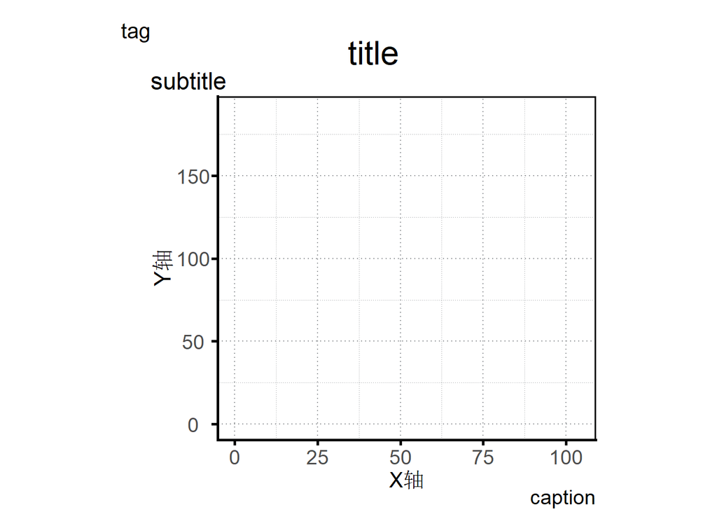

```r
> p空白 <- p两变量框架+
+   geom_blank(mapping = NULL,data = NULL,stat = "identity",position = "identity",show.legend = NA,inherit.aes = TRUE)+
+   coord_fixed(ratio = 20/40)+
+   expand_limits(x = 0, y = 0)+
+   labs(x = "X轴", y = "Y轴", title = "title", subtitle = "subtitle", caption = "caption", tag = "tag")
> p空白
```

## 4.5 一个定量变量

### 4.5.1 QQ图+QQ线

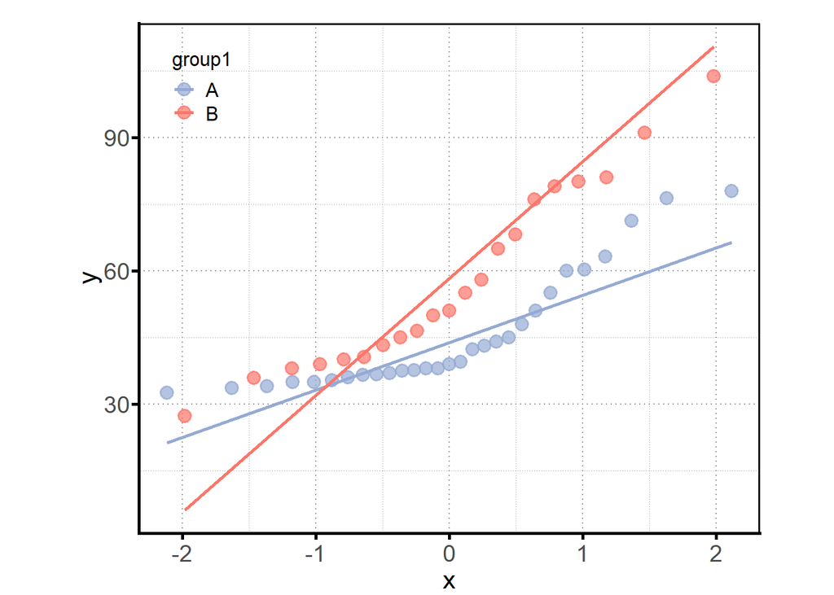

```r
> pQQ图 <- pQQ框架+
+   stat_qq(size = 3, shape = 21, alpha = 0.7, stroke = 1, geom = "point")+
+   stat_qq_line(size = 1, linetype = 1, geom = "path")+
+   scale_color_manual(values = cols)+
+   scale_fill_manual(values = fills)+
+   theme(legend.position = (c(0.15, 0.95)))+
+   coord_fixed(ratio = 1/30)
> pQQ图
```

### 4.5.2 折线直方图

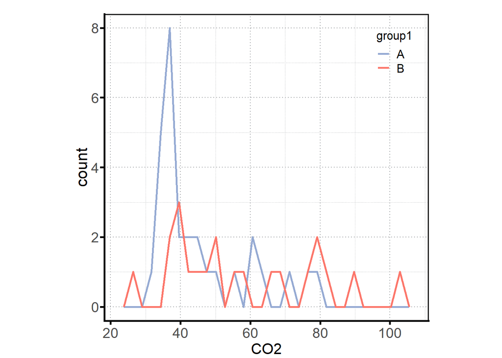

```r
> p折线直方图 <- p单一变量框架+
+   geom_freqpoly(size = 1, alpha = 1, stat = "bin")+
+   scale_color_manual(values = cols)+
+   scale_fill_manual(values = fills)+
+   theme(legend.position = (c(0.95, 0.95)))+
+   coord_fixed(ratio = 20/2)
> p折线直方图
```

### 4.5.3 点直方图

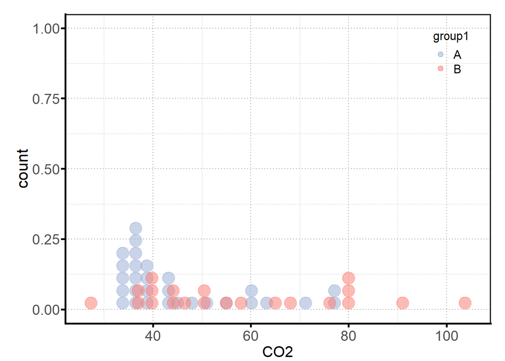

```r
> p点直方图 <- p单一变量框架+
+   geom_dotplot(size = 1, alpha = 0.5, shape = 21, stroke = 1)+
+   scale_color_manual(values = cols)+
+   scale_fill_manual(values = fills)+
+   theme(legend.position = (c(0.95, 0.95)))
> #coord_fixed(ratio = 100/2)+
> #coord_cartesian(ylim = c(0, 0.2))
> p点直方图
```

### 4.5.4 直方图

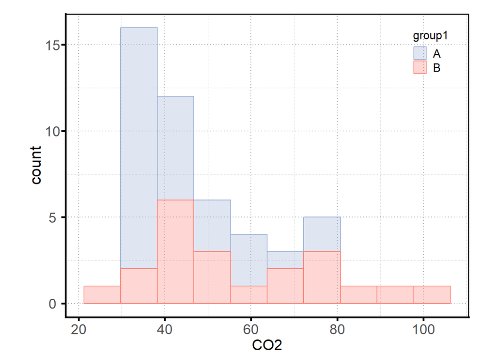

```r
> p直方图 <- p单一变量框架+
+   geom_histogram(alpha = 0.3, bins = 10, stat = "bin")+
+   scale_color_manual(values = cols)+
+   scale_fill_manual(values = fills)+
+   theme(legend.position = (c(0.95, 0.95)))+
+   coord_fixed(ratio = 20/5)
> p直方图
```

### 4.5.5 密度曲线

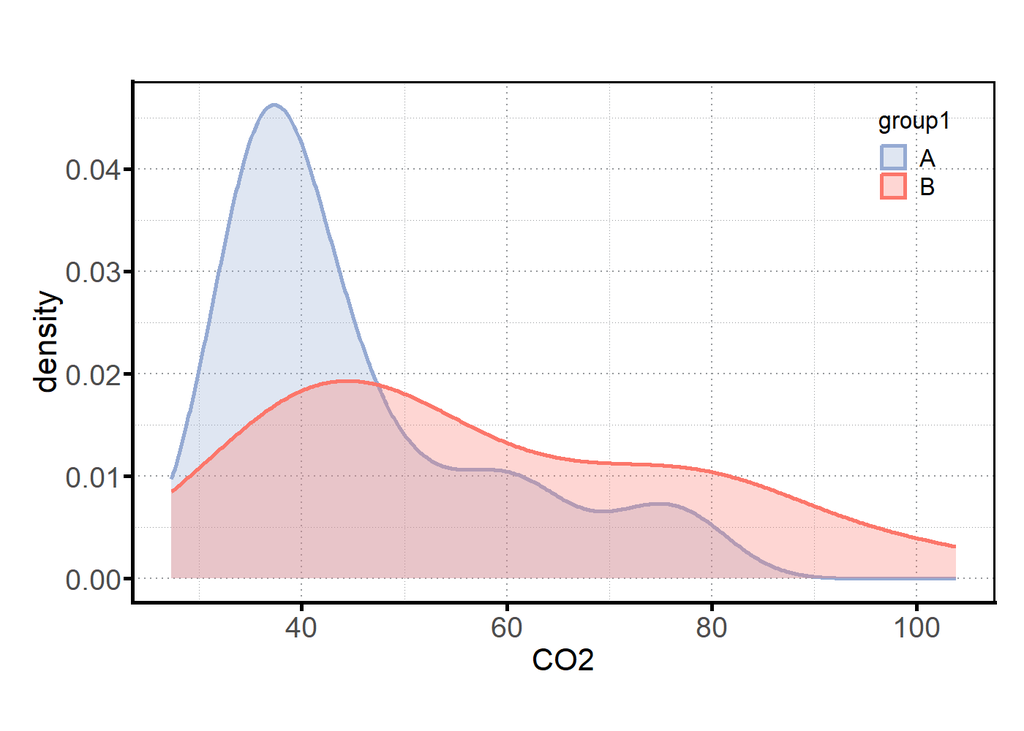

```r
> p密度曲线 <- p单一变量框架+
+   geom_density(size = 1, alpha = 0.3, linetype = 1, stat = "density")+
+   scale_color_manual(values = cols)+
+   scale_fill_manual(values = fills)+
+   theme(legend.position = (c(0.95, 0.95)))+
+   coord_fixed(ratio = 10/0.01)
> p密度曲线
```

## 4.6 两个变量都为定量变量

### 4.6.1 散点图

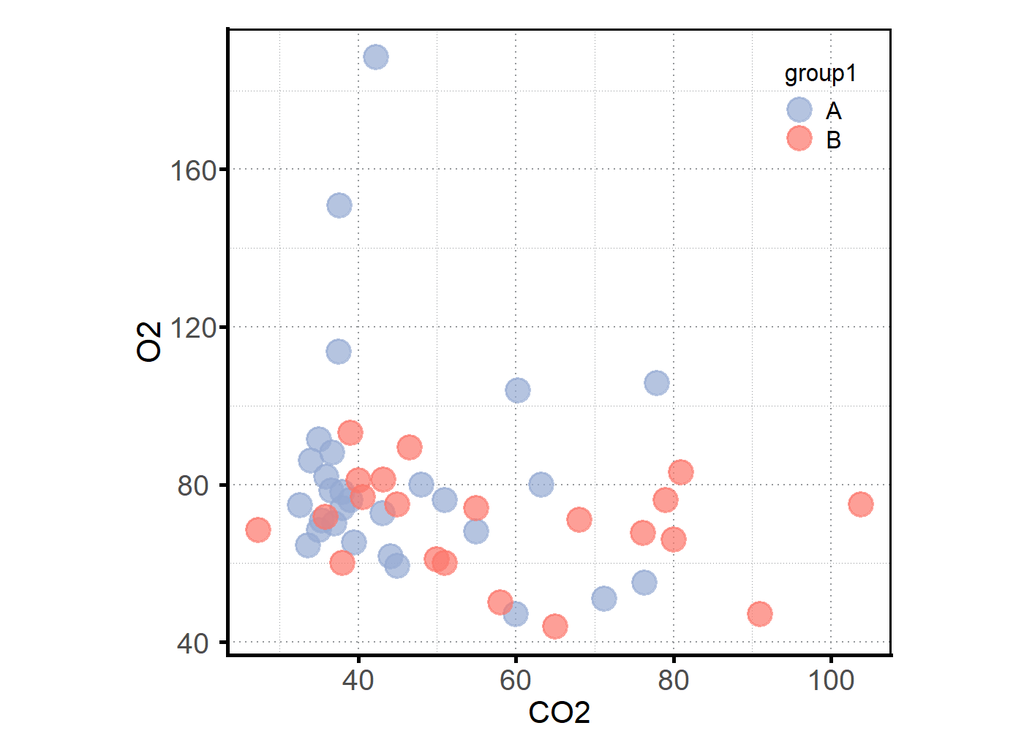

```r
> p散点图 <- p两变量框架+
+   geom_point(size = 5, shape = 21, alpha = 0.7, stroke = 1, stat = "identity")+
+   scale_color_manual(values = cols)+
+   scale_fill_manual(values = fills)+
+   theme(legend.position = (c(0.95, 0.95)))+
+   coord_fixed(ratio = 20/40)
> p散点图
```

### 4.6.2 边际图

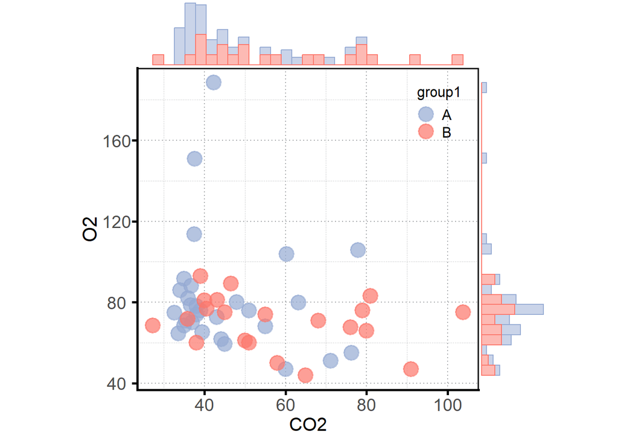

```r
> p边际图 <- ggMarginal(p散点图, type = "histogram", groupColour = T, groupFill = T)
> p边际图
```

### 4.6.3 避免重叠

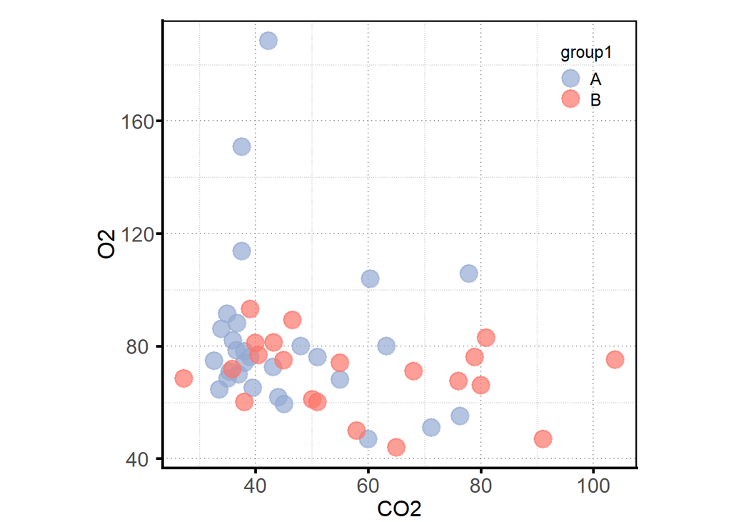

```r
> p抖动点 <- p两变量框架+
+   geom_jitter(size = 5, shape = 21, alpha = 0.7, width = 0.05, height = 0.05, stroke = 1, stat = "identity")+
+   scale_color_manual(values = cols)+
+   scale_fill_manual(values = fills)+
+   theme(legend.position = (c(0.95, 0.95)))+
+   coord_fixed(ratio = 20/40)
> p抖动点
```

### 4.6.4 顺序连接图

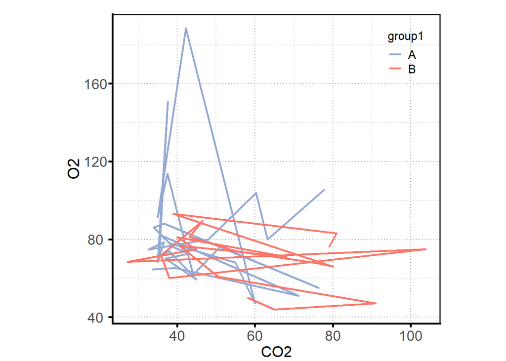

```r
> p顺序连接图 <- p两变量框架+
+   geom_path(size = 1, linetype = 1, alpha = 1, stat = "identity")+
+   scale_color_manual(values = cols)+
+   scale_fill_manual(values = fills)+
+   theme(legend.position = (c(0.95, 0.95)))+
+   coord_fixed(ratio = 20/40)
> p顺序连接图
```

### 4.6.5 折线图

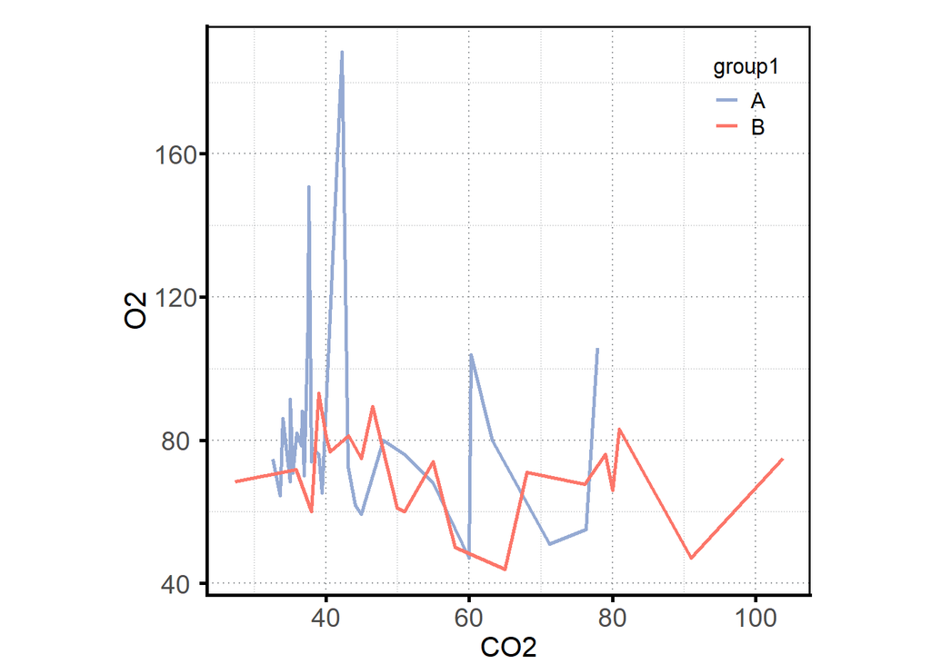

```r
> p折线图 <- p两变量框架+
+   geom_line(size = 1, linetype = 1, alpha = 1, stat = "identity")+
+   scale_color_manual(values = cols)+
+   scale_fill_manual(values = fills)+
+   theme(legend.position = (c(0.95, 0.95)))+
+   coord_fixed(ratio = 20/40)
> p折线图
```

### 4.6.6 地毯线

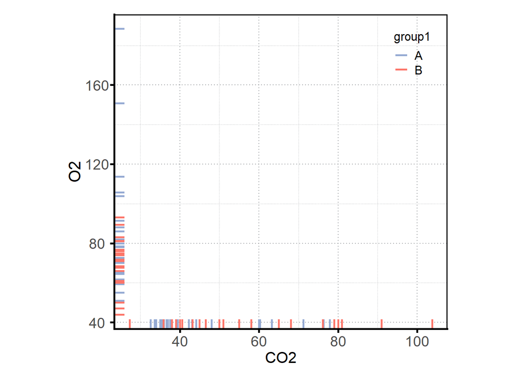

```r
> p地毯线 <- p两变量框架+
+   geom_rug(size = 1, linetype = 1, alpha = 1, stat = "identity")+
+   scale_color_manual(values = cols)+
+   scale_fill_manual(values = fills)+
+   theme(legend.position = (c(0.95, 0.95)))+
+   coord_fixed(ratio = 20/40)
> p地毯线
```

### 4.6.7 拟合分位数的回归线

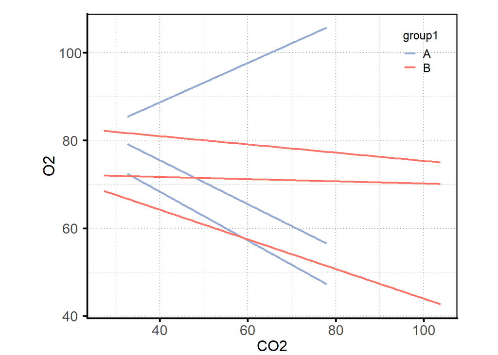

```r
> p分位数回归 <- p两变量框架+
+   geom_quantile(size = 1, linetype = 1, alpha = 1, stat = "quantile")+
+   scale_color_manual(values = cols)+
+   scale_fill_manual(values = fills)+
+   theme(legend.position = (c(0.95, 0.95)))+
+   coord_fixed(ratio = 20/20)
> p分位数回归
```

### 4.6.8 拟合曲线

拟合一条平滑曲线, 并显示标准误, 其中fill部分是置信区间, (se = FALSE)即可取消灰色部分。  
**通过改变 method可以设置曲线平滑度等多种参数, 包括几种类型:**

#### 4.6.8.1 数据量小

method = “loess”:在数据量较小时默认使用。 span参数控制曲线的平滑程度, 其取值范围是0~1(从很不平滑到很平滑)

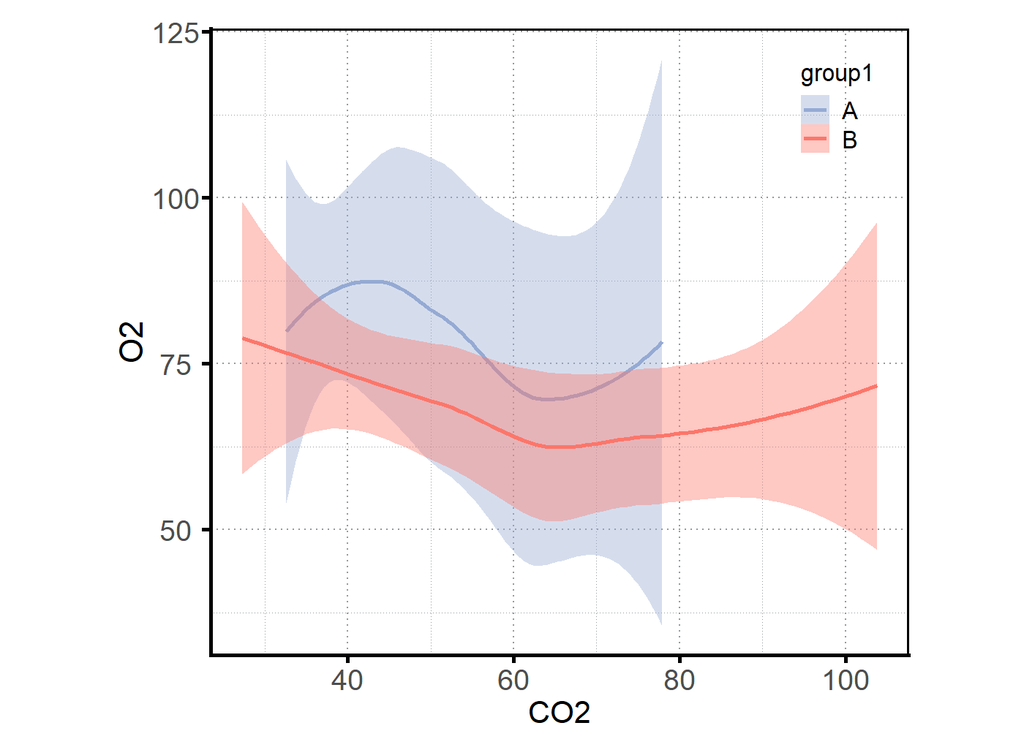

```r
> p拟合曲线 <- p两变量框架+
+   geom_smooth(size = 1, linetype = 1, alpha = 0.4, method = "loess", span = 1, stat = "smooth")+#, se = FALSE
+   scale_color_manual(values = cols)+
+   scale_fill_manual(values = fills)+
+   theme(legend.position = (c(0.95, 0.95)))+
+   coord_fixed(ratio = 20/25)
> p拟合曲线
```

#### 4.6.8.2 数据量大

在数据量n>1000时 method = “gam”:此算法通过调用(mgcv包)拟合一个广义可加模型, 使用formula = y~s(x) 或y~s(x, bs = “cs”)公式。

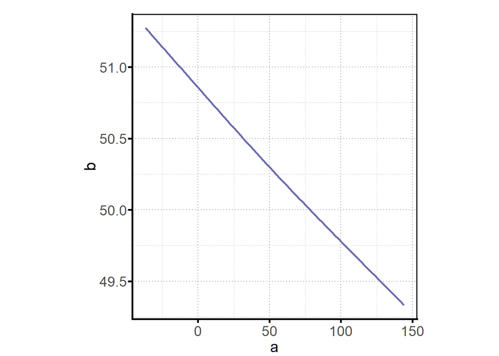

```r
> p数据量大1 <- p大框架+
+   geom_smooth(size = 1, linetype = 1, alpha = 0.4, method = "gam", formula = y~ s(x), color = "#696AAD", se = FALSE, fill = "#95AAD3", stat = "smooth")+
+   coord_fixed(ratio = 50/0.5)
> p数据量大1
```

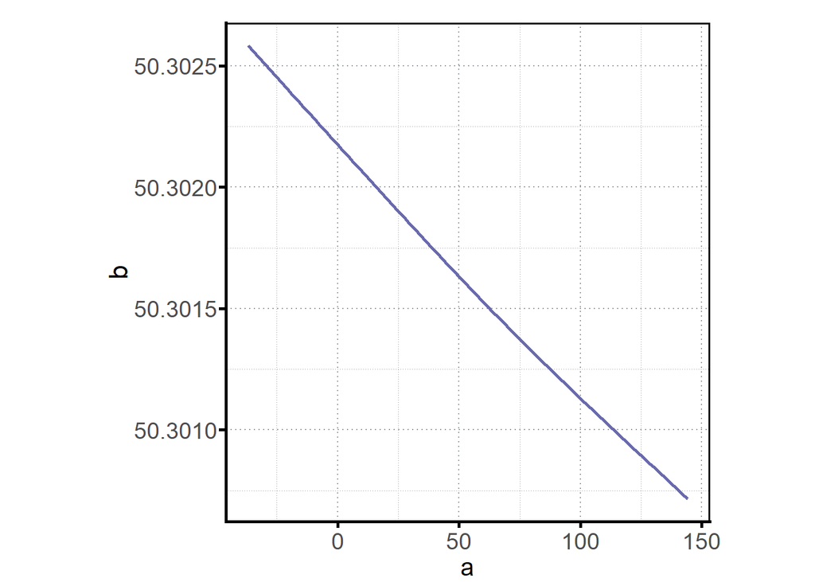

```r
> p数据量大2 <- p大框架+
+   geom_smooth(size = 1, linetype = 1, alpha = 0.4, method = "gam", formula = y ~s(x, bs = "cs"), color = "#696AAD", se = FALSE, fill = "#95AAD3", stat = "smooth")+
+   coord_fixed(ratio = 50/0.0005)
> p数据量大2
```

#### 4.6.8.3 线性回归

(ggpmisc包)  
method = “lm”和method = “rlm”：这两种算法拟合的是线性模型, 默认条件下回生成一条直线。可以通过添加二项式改变自由度使曲线波动变大。后者对异常值不敏感, 但在使用前需要先加载MASS包

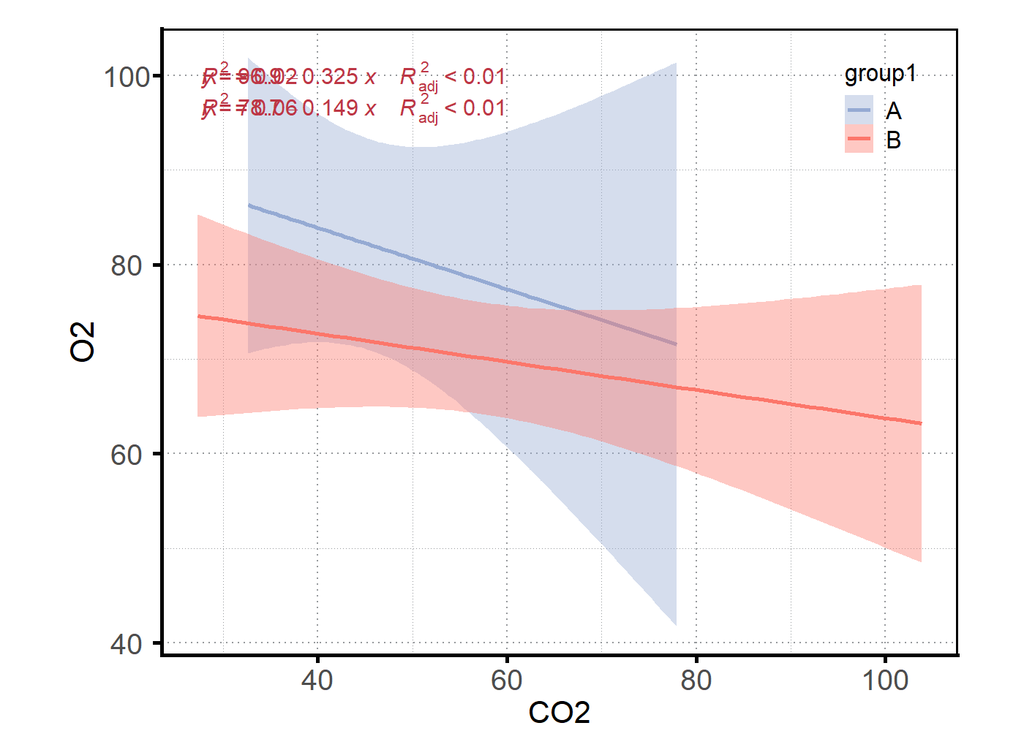

```r
> p拟合直线 <- p两变量框架+
+   geom_smooth(size = 1, linetype = 1, alpha = 0.4, method = "lm", stat = "smooth")+#, se = FALSE(MASS包)
+   stat_poly_eq(aes(label = paste(..eq.label.., ..adj.rr.label.., sep = "~~~~")), formula = y ~ x, parse = T, color = "#BD3645")+
+   stat_poly_eq(
+     color = "#BD3645",
+     geom = "text_npc",
+     position = "identity",
+     method = "lm",
+     method.args = list(),
+     formula = NULL,
+     eq.with.lhs = TRUE,
+     eq.x.rhs = NULL,
+     small.r = FALSE,
+     small.p = FALSE,
+     coef.digits = 3,
+     coef.keep.zeros = TRUE,
+     rr.digits = 2,
+     f.digits = 3,
+     p.digits = 3,
+     label.x = "left",
+     label.y = "top",
+     label.x.npc = NULL,
+     label.y.npc = NULL,
+     hstep = 0,
+     vstep = NULL,
+     output.type = NULL,
+     na.rm = FALSE,
+     orientation = NA,
+     parse = NULL,
+     show.legend = FALSE,
+     inherit.aes = TRUE)+
+   scale_color_manual(values = cols)+
+   scale_fill_manual(values = fills)+
+   theme(legend.position = (c(0.95, 0.95)))+
+   coord_fixed(ratio = 20/20)
> p拟合直线
```

### 4.6.9 面积图

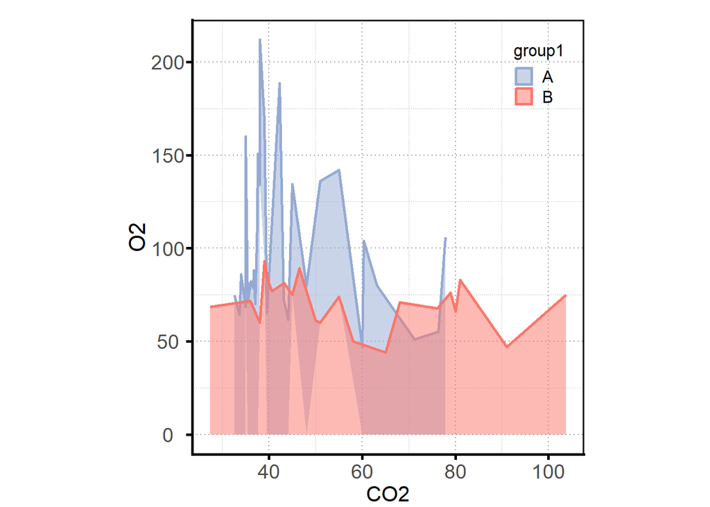

```r
> p面积图 <- p两变量框架+
+   geom_area(size = 1, linetype = 1, alpha = 0.5, stat = "identity")+
+   scale_color_manual(values = cols)+
+   scale_fill_manual(values = fills)+
+   theme(legend.position = (c(0.95, 0.95)))+
+   coord_fixed(ratio = 20/50)
> p面积图
```

### 4.6.10 阶梯图

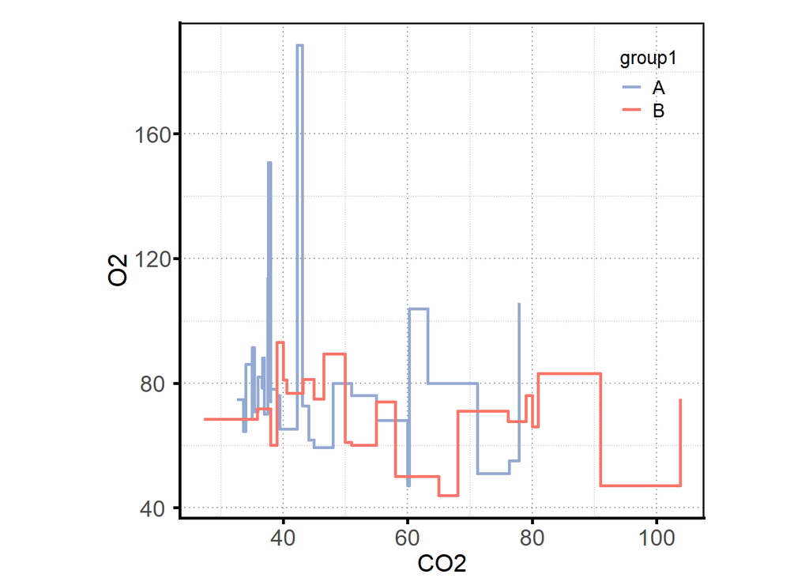

```r
> p阶梯图 <- p两变量框架+
+   geom_step(size = 1, linetype = 1, alpha = 1, stat = "identity")+
+   scale_color_manual(values = cols)+
+   scale_fill_manual(values = fills)+
+   theme(legend.position = (c(0.95, 0.95)))+
+   coord_fixed(ratio = 20/40)
> p阶梯图
```

### 4.6.11 二维直方图

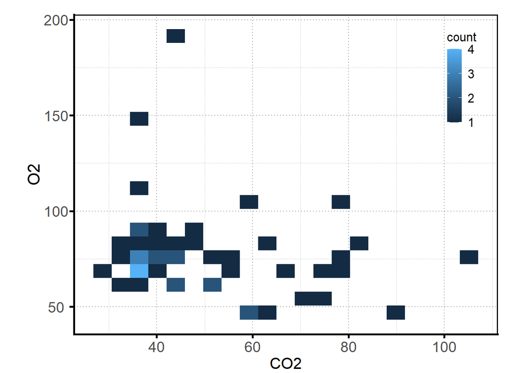

```r
> p二维直方图 <- p两变量颜色框架+
+   geom_bin2d(bins = 20, alpha = 1, color = NA, stat = "bin2d")+
+   theme(legend.position = (c(0.95, 0.95)))+
+   coord_fixed(ratio = 20/50)
> p二维直方图
```

### 4.6.12 二维等高线图

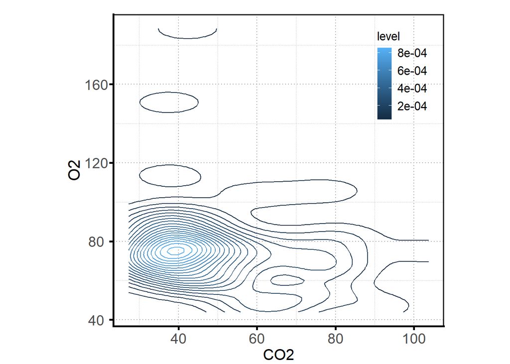

```r
> p二维等高线图 <- p两变量颜色框架+
+   geom_density_2d(aes(color = ..level..), bins = 20, alpha = 1, size = 0.5, stat = "density_2d")+
+   theme(legend.position = (c(0.95, 0.95)))+
+   coord_fixed(ratio = 20/40)
> p二维等高线图
```

### 4.6.13 二维等高线颜色密度图

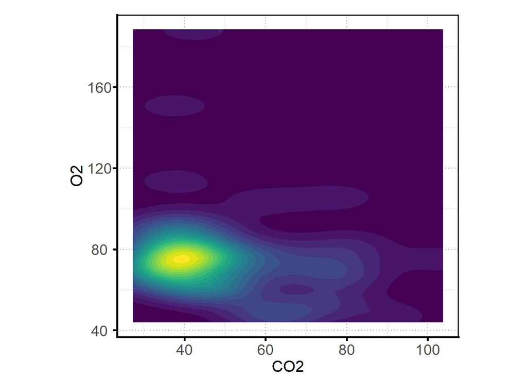

```r
> p二维等高线颜色密度图 <- p两变量颜色框架+
+   geom_density_2d_filled(bins = 20, alpha = 1, show.legend = F)+
+   coord_fixed(ratio = 20/40)
> p二维等高线颜色密度图
```

### 4.6.14 六边形二维直方图

(hexbin包)

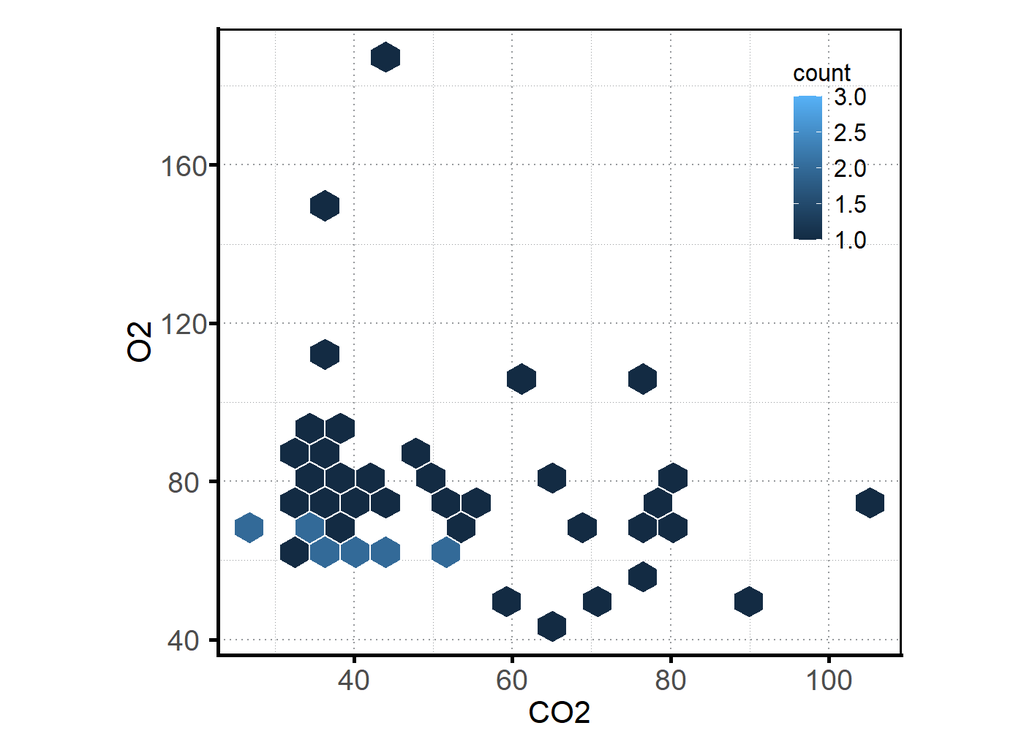

```r
> p六边形二维直方图 <- p两变量颜色框架+
+   geom_hex(bins = 20, alpha = 1, color = "#FFFFFF", size = 0.5)+
+   theme(legend.position = (c(0.95, 0.95)))+
+   coord_fixed(ratio = 20/40)
> p六边形二维直方图
```

### 4.6.15 散点图和二维密度图之间的交叉

(ggpointdensity包)

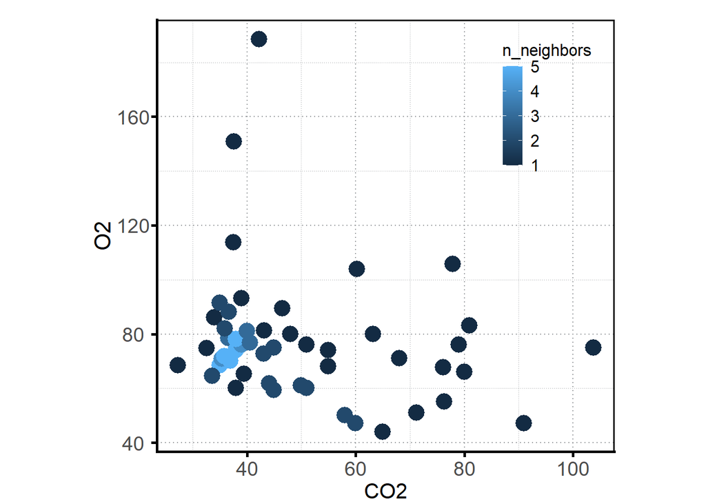

```r
> p交叉图 <- p两变量颜色框架+
+   geom_pointdensity(method = "auto", adjust = 4, alpha = 1, size = 5, shape = 16, stroke = 1)+#"default""kde2d"
+   theme(legend.position = (c(0.95, 0.95)))+
+   coord_fixed(ratio = 20/40)
> p交叉图
```

### 4.6.16 透明度

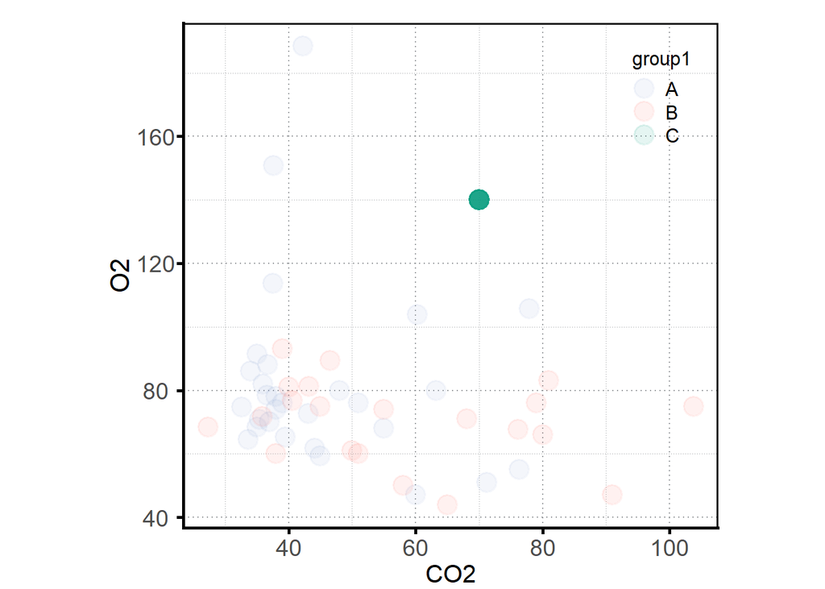

```r
> qc <- data.table(
+   CO2 = c(rep(70,times = 20)),
+   O2 = c(rep(140,times = 20)),
+   group1 = c(rep("C",times = 20)))
> qdt <- rbindlist(list(q, qc), fill = T)
> p频率气泡图 <- ggplot(qdt, aes(x = CO2, y = O2, color = group1, fill = group1))+
+   geom_point(size=5, shape = 21, alpha = 0.1, stroke = 1, stat = "identity")+
+   scale_color_manual(values = cols)+
+   scale_fill_manual(values = fills)+
+   t_theme+
+   theme(legend.position = (c(0.95, 0.95)))+
+   coord_fixed(ratio = 20/40)
> p频率气泡图
```

### 4.6.17 频率气泡图

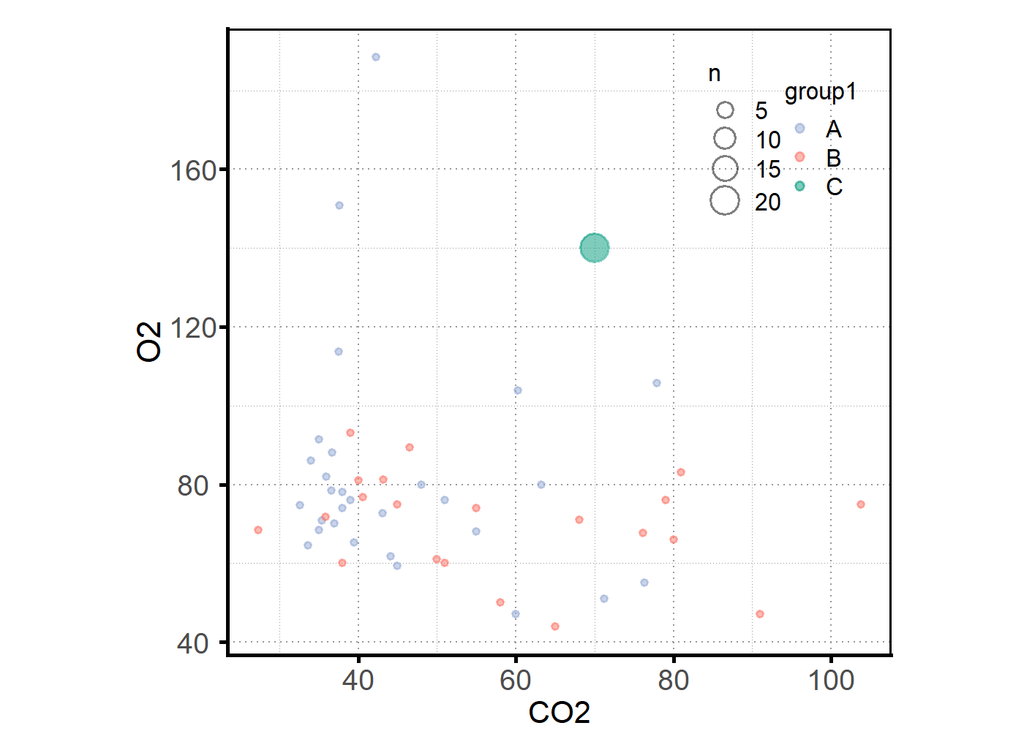

```r
> p频率气泡图 <- ggplot(qdt, aes(x = CO2, y = O2, color = group1, fill = group1))+
+   geom_point(shape = 21, alpha = 0.5, stroke = 1, stat = "sum")+
+   scale_color_manual(values = cols)+
+   scale_fill_manual(values = fills)+
+   t_theme+
+   theme(legend.position = (c(0.95, 0.95)))+
+   coord_fixed(ratio = 20/40)
> p频率气泡图
```

### 4.6.18 特殊

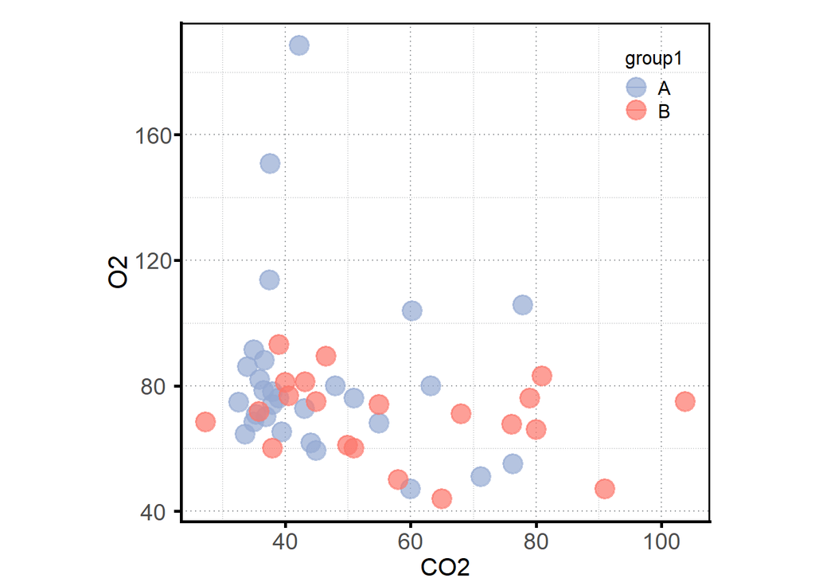

```r
> p特殊图 <- ggplot(q, aes(x = CO2, y = O2, color = group1, fill = group1))+
+   geom_point(size = 5, shape = 21, alpha = 0.7, stroke = 1, stat = "identity")+
+   stat_summary(aes(x = mean(CO2), color = group1, fill = group1), width=0.1, geom = "errorbar", fun = "mean")+
+   stat_summary(aes(y = mean(O2), color = group1, fill = group1), width=0.1, geom = "errorbar", fun = "mean")+
+   scale_color_manual(values = cols)+
+   scale_fill_manual(values = fills)+
+   t_theme+
+   theme(legend.position = (c(0.95, 0.95)))+
+   coord_fixed(ratio = 20/40)
> p特殊图
```

## 4.7 四个定量变量

### 4.7.1 气泡图

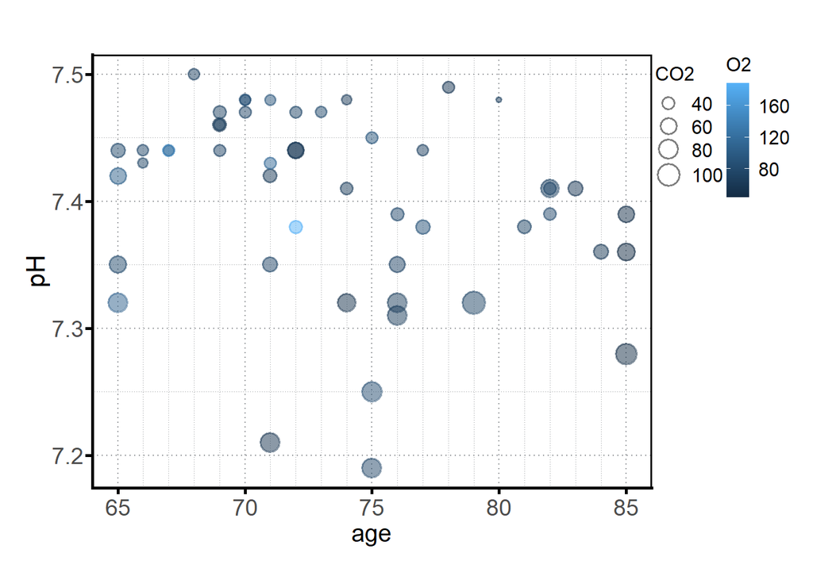

```r
> p气泡图 <- p四变量框架+
+   geom_point(alpha = 0.5, shape = 21, stroke = 1, stat = "identity")+
+   scale_y_continuous(breaks = seq(7, 7.5, by = 0.1), minor_breaks = seq(7, 7.5, 0.05))+
+   scale_x_continuous(breaks = seq(60, 90, by = 5), minor_breaks = seq(60, 90, 1))+
+   #scale_size_continuous(range = c(5, 15))+
+   coord_fixed(ratio = 5/0.1)
> p气泡图
```

## 4.8 一个定量变量和一个定性变量/等级变量

### 4.8.1 点图

(ggbeeswarm包)

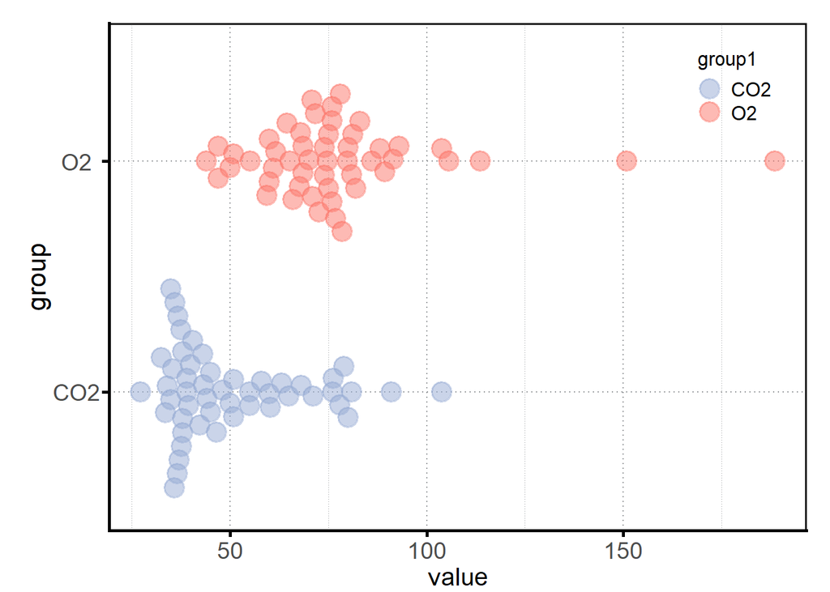

```r
> p点图 <- p分组框架+
+   geom_beeswarm(aes(group = group, color = group, fill = group), cex = 3, priority = "density", size = 5, shape = 21, alpha = 0.5, stroke = 1)+
+   #"descending""density""random""none"点图)
+   theme(legend.position = (c(0.95, 0.95)))+
+   scale_color_manual(values = cols)+
+   scale_fill_manual(values = fills)
> p点图
```

### 4.8.2 条图

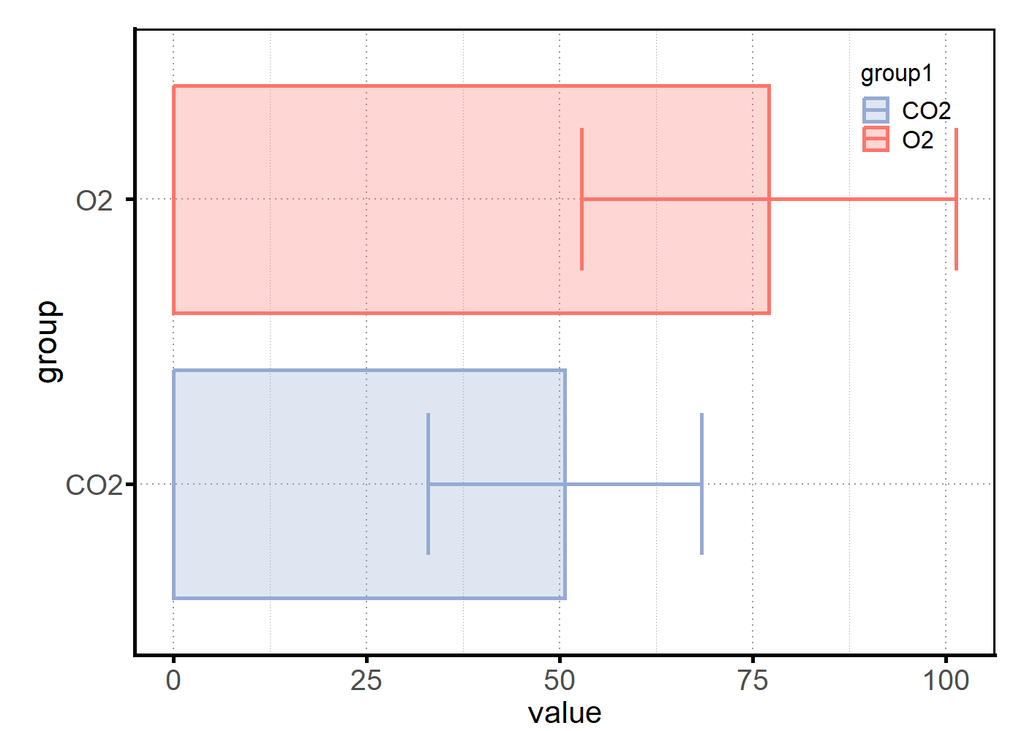

```r
> p条图 <- p分组框架+
+   stat_summary(aes(color = group, fill = group), fun.data = mean_sdl, fun.args = list(mult = 1), geom = "errorbar", width = 0.5, size = 1, alpha = 1, position = position_dodge(width = 1))+
+   stat_summary(aes(color = group, fill = group), fun.data = mean_sdl, fun.args = list(mult = 1), geom = "col", width = 0.8, size = 1, alpha = 0.3, position = position_dodge(width = 1))+
+   #geom_text(aes(label=mean_sdl), vjust=0, size=3.5)+
+   theme(legend.position = (c(0.95, 0.95)))+
+   scale_color_manual(values = cols)+
+   scale_fill_manual(values = fills)
> p条图
```

### 4.8.3 棒棒糖图

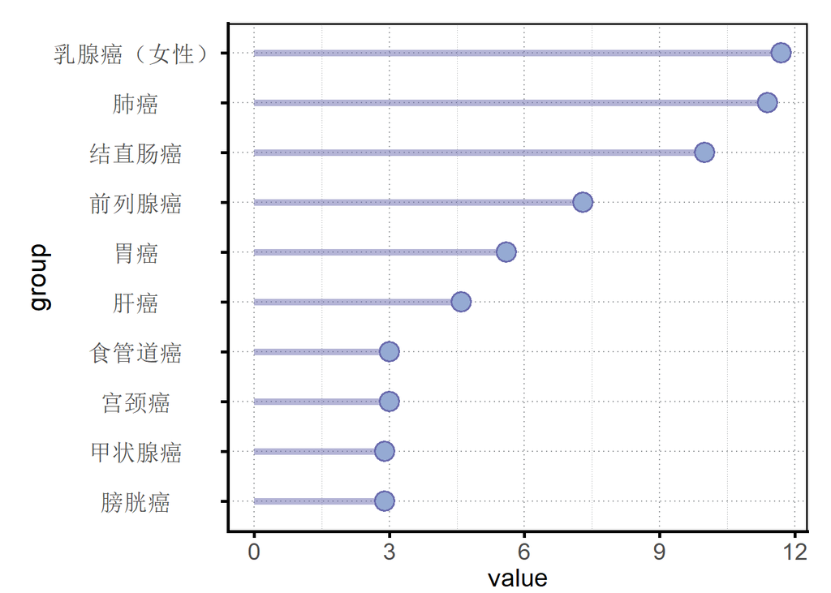

```r
> x <- import("D:/desktop/book/book/case/2020年全球癌症诊断数目最多的十个癌症.xlsx")
> p框架 <- ggplot(x, aes(x = group, y = value))+coord_flip()
> p棒棒糖图 <- p框架+
+   geom_segment(aes(x = reorder(group, value), xend = reorder(group, value), y = 0, yend = value), size = 2, alpha = 0.5, color = "#696AAD", fill = "#95AAD3", stat = "identity")+
+   geom_point(shape = 21, size = 5, color = "#696AAD", fill = "#95AAD3", stroke = 1, stat = "identity")+
+   t_theme
> p棒棒糖图
```

### 4.8.4 箱线图#notch = TRUE

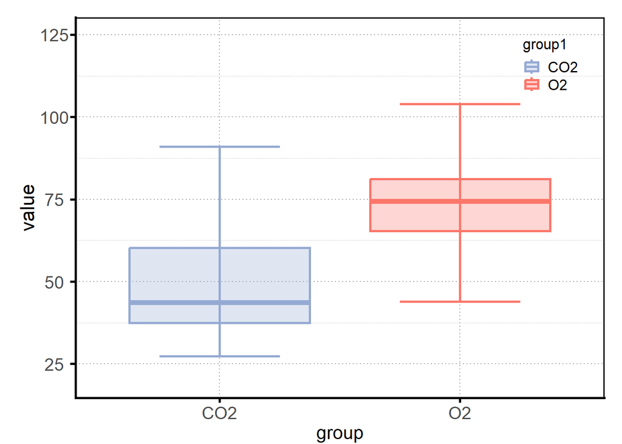

```r
> p箱线图 <- p分组框架+
+   stat_boxplot(aes(group = group, color = group, fill = group), fun = "mean", alpha = 0.3, size = 1, outlier.shape = NA, geom = "boxplot")+
+   stat_boxplot(aes(group = group, color = group, fill = group), geom = "errorbar", width = 0.5, linetype = 1, size = 1)+
+   scale_color_manual(values = cols)+
+   scale_fill_manual(values = fills)+
+   theme(legend.position = (c(0.95, 0.95)))+
+   coord_cartesian(ylim = c(20, 125))
> p箱线图
```